# Neo4j con Python

http://nicolewhite.github.io/neo4j-jupyter/hello-world.html

## py2neo

py2neo is one of Neo4j's Python drivers. It offers a fully-featured interface for interacting with your data in Neo4j.

http://py2neo.org/v3/#

```python
import py2neo
print(py2neo.__version__)
```

```
2021.2.0
```

## Connect

Connect to Neo4j with the Graph class.

```python
from py2neo import Graph

graph = Graph()
```

```python
graph.delete_all()
```

## Nodes

Create nodes with the Node class. The first argument is the node's label. The remaining arguments are an arbitrary amount of node properties or key-value pairs.

```python
from py2neo import Node
```

```python
nicole = Node("Person", name="Nicole", age=24)
drew = Node("Person", name="Drew", age=20)

mtdew = Node("Drink", name="Mountain Dew", calories=9000)
cokezero = Node("Drink", name="Coke Zero", calories=0)

coke = Node("Manufacturer", name="Coca Cola")
pepsi = Node("Manufacturer", name="Pepsi")

graph.create(nicole | drew | mtdew | cokezero | coke | pepsi)
```

```python
drew.update(city = 'NY', country = 'US')
graph.push(drew)
```

We have only one Nicole!

```python
same_nicole = Node("Person", name="Nicole", age=24)
graph.merge(same_nicole, 'Person',  'name')
```

## Visualization

```python
%%HTML
<script src="https://cdnjs.cloudflare.com/ajax/libs/require.js/2.3.6/require.js"></script>
```

```python
import neo4jupyter
neo4jupyter.init_notebook_mode()
```

```python
options = {"Person": "name", "Drink": "name", "Manufacturer": "name"}

neo4jupyter.draw(graph, options)
```

[output not shown]

## Relationships

Create relationships between nodes with the Relationship class.

```python
from py2neo import Relationship

rel_nicole_cokezero = Relationship(nicole, "LIKES", cokezero)
rel_nicole_mtdew = Relationship(nicole, "LIKES", mtdew)
rel_drew_mtdew = Relationship(drew, "LIKES", mtdew)
rel_coke_cokezero = Relationship(coke, "MAKES", cokezero)
rel_pepsi_mtdew = Relationship(pepsi, "MAKES", mtdew)

graph.create(rel_nicole_cokezero | rel_nicole_mtdew | rel_drew_mtdew |  rel_coke_cokezero | rel_pepsi_mtdew)
```

```python
neo4jupyter.draw(graph, options)
```

[output not shown]

## Relationships with atributes

```python
rel_drew_pepsi = Relationship(drew, "WORKS", pepsi, years = 5)

graph.create(rel_drew_pepsi)
```

## Cypher

```python
query = """
MATCH (person:Person)-[:LIKES]->(drink:Drink)
RETURN person.name AS name, person.city as City, drink.name AS drink
"""

data = graph.run(query)

for d in data:
    print(d)
```

```
'Nicole'	None	'Mountain Dew'
'Drew'	'NY'	'Mountain Dew'
'Nicole'	None	'Coke Zero'
```

## Parameterized Cypher

```python
query = """
MATCH (p:Person)-[:LIKES]->(drink:Drink)
WHERE p.name = {name}
RETURN p.name AS name, AVG(drink.calories) AS avg_calories
"""

data = graph.run(query, name="Nicole")

for d in data:
    print(d)
```

```
'Nicole'	4500.0
```

## ipython-cypher

ipython-cypher exposes %cypher magic in Jupyter. Install ipython-cypher with pip install ipython-cypher.

```python
%load_ext cypher
```

## Cypher

%cypher is intended for one-line Cypher queries and %%cypher is intended for multi-line Cypher queries. Placing %%cypher above a Cypher query will display that query's results.

```python
%%cypher
MATCH (person:Person)-[:LIKES]->(drink:Drink)
RETURN person.name, drink.name, drink.calories
```

```
3 rows affected.
```

| person.name | drink.name | drink.calories |
| --- | --- | --- |
| Drew | Mountain Dew | 9000 |
| Nicole | Mountain Dew | 9000 |
| Nicole | Coke Zero | 0 |

## Pandas Data Frames

Cypher query results can be coerced to pandas data frames with the get_dataframe method. To assign Cypher query results to a variable, you need to use **%cypher** and separate lines with \

You'll first need to install pandas with pip install pandas.

```python
results = %cypher MATCH (person:Person)-[:LIKES]->(drink:Drink) \
                  RETURN person.name AS name, drink.name AS drink

df = results.get_dataframe()

df
```

```
3 rows affected.
```

|  | name | drink |
| --- | --- | --- |
| 0 | Nicole | Mountain Dew |
| 1 | Drew | Mountain Dew |
| 2 | Nicole | Coke Zero |

## NetworkX Graphs

Cypher query results can be coerced to NetworkX MultiDiGraphs, graphs that permit multiple edges between nodes, with the get_graph method

```
3 rows affected.
```

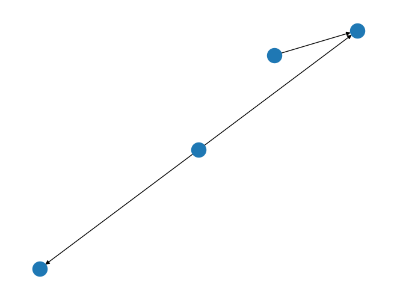

```python
import networkx as nx
%matplotlib inline

results = %cypher MATCH p = (:Person)-[:LIKES]->(:Drink) RETURN p

g = results.get_graph()

nx.draw(g)
```

```python
g.nodes(data=True)
```

```
NodeDataView({'1': {'name': 'Nicole', 'age': 24, 'labels': ['Person']}, '2': {'name': 'Mountain Dew', 'calories': 9000, 'labels': ['Drink']}, '0': {'country': 'US', 'city': 'NY', 'name': 'Drew', 'age': 20, 'labels': ['Person']}, '3': {'name': 'Coke Zero', 'calories': 0, 'labels': ['Drink']}})
```

```python
nx.degree(g)
```

```
DiMultiDegreeView({'1': 2, '2': 2, '0': 1, '3': 1})
```